# Oil Heating Prediction: Deep Learning Time Series Forecasting

Author

Jorge Bris Moreno

## Introduction

This project presents a comprehensive evaluation of state of the art deep learning models for time series forecasting applied to oil heating temperature prediction. The system addresses the critical challenge of predicting oil temperature 4 hours ahead (16 time steps at 15-minute intervals) to enable proactive maintenance and operational optimization in industrial heating systems. While the full details of the implementation will not be publicly available, here is a brief overview of the project:

## Problem Statement

Accurate temperature forecasting is essential for:

- **Preventive maintenance**: Early detection of potential overheating or system failures
- **Energy optimization**: Anticipating heating requirements to reduce energy consumption
- **Operational safety**: Ensuring temperatures remain within safe operating ranges
- **Cost reduction**: Minimizing downtime and emergency repairs through predictive insights

## Solution Overview

The project implements a rigorous experimental framework comparing 8 cutting-edge deep learning architectures, each optimized through automated hyperparameter tuning. The models span different architectural paradigms.

### Methodology

1. **Data Preparation & Feature Engineering**:
   - **Temporal splits**: Strict chronological division (70% train → 15% validation → 15% test) to prevent data leakage
   - **Cyclical time encoding**: Sine/cosine transformations for hour (24h cycle), day of week (7-day cycle), and month (12-month cycle) to capture periodic patterns
   - **Exogenous variables**: Six electrical load channels (HUFL, HULL, MUFL, MULL, LUFL, LULL) for multivariate models
   - **Normalization pipeline**: `StandardScaler` fitted **only on training data** with frozen parameters ($\mu$, $\sigma$) applied to validation and test sets, mimicking production constraints where future statistics are unknown
   - **Denormalization**: All metrics (RMSE, MAE) reported in original temperature units (°C) via inverse scaling, not z-scores
2. **Hyperparameter Optimization**:
   - **Framework**: Optuna with Tree-structured Parzen Estimator (TPE) algorithm
   - **Scale**: 100 trials per model (800 total trials across 8 models)
   - **Search space**: Learning rates (log-uniform), batch sizes, model dimensions, architecture-specific parameters (layers, attention heads, kernel sizes, dilations)
   - **Input window optimization**: Different input windows were tested for each model, with the best performing window being selected based on the validation set performance.
   - **Trial pruning**: Invalid trials (NaN/inf predictions, insufficient data, errors) are pruned using `optuna.TrialPruned` rather than failing, ensuring optimization continues robustly
3. **Model Training & Regularization**:
   - **Early stopping**: Patience of 30 steps monitoring validation loss to prevent overfitting
   - **GPU acceleration**: CUDA-enabled training with PyTorch Lightning for efficient computation
   - **Memory management**: Strategic GPU memory clearing after each trial and model to prevent OOM errors during long runs
   - **RevIN (Reversible Instance Normalization)**: Enabled for many of the models to improve generalization across different time series scales
   - **Exog gating**: Explicit handling of models that don’t support exogenous variables by forcing `hist_exog_list=None`, while multivariate models receive full feature sets
4. **Evaluation Protocol**:
   - **Rolling cross-validation**: Models evaluated on 653 non-overlapping test windows, each 4 hours (16 steps) ahead, simulating real-world operational deployment
   - **Robustness**: Performance aggregated across multiple time periods rather than single train/test split, accounting for temporal variability
   - **Constraint handling**: Automatic test size adjustment to satisfy CV requirements: `(test_size - horizon) % step_size == 0`

## Results

The comprehensive evaluation yielded the following performance metrics (RMSE, MAE, MSE) on the test set:

| Model | Input Window | RMSE | MAE | MSE | Test Windows |
| --- | --- | --- | --- | --- | --- |
| **Model 1** | 96 | **1.4833** | **0.8823** | **2.2002** | 653 |
| Model 2 | 336 | 1.8375 | 1.1621 | 3.3766 | 653 |
| Model 3 | 96 | 1.6120 | 0.9693 | 2.5985 | 653 |
| Model 4 | 96 | 1.7950 | 1.1020 | 3.2219 | 653 |
| Model 5 | 192 | 1.9377 | 1.3486 | 3.7545 | 653 |
| Model 6 | 192 | 2.0067 | 1.3130 | 4.0269 | 653 |
| Model 7 | 96 | 2.1049 | 1.3290 | 4.4304 | 653 |
| Model 8 | 336 | 2.1117 | 1.3514 | 4.4592 | 653 |

**Key Findings:**

- **Model 1 achieved the best performance** with RMSE of 1.48°C, demonstrating the effectiveness of patch-based attention mechanisms for this task
- Univariate models outperformed most multivariate approaches, suggesting the time series signal itself contains sufficient predictive information
- Optimal input windows varied by model (96-336 steps), highlighting the importance of architecture-specific hyperparameter tuning

### Visualization

The following plot shows Model 1’s forecast performance on the test set, demonstrating the model’s ability to accurately capture both short-term fluctuations and longer-term trends in oil temperature:

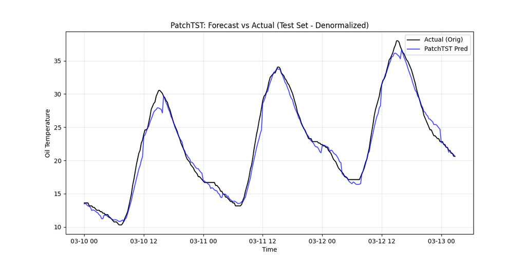

The visualization shows the alignment between predicted and actual temperatures, with the model successfully tracking the time series dynamics across 300 time steps of the test set.

## Technical Implementation

The project was built using:

- **NeuralForecast**: Time series forecasting library
- **Optuna**: Automated hyperparameter optimization framework
- **PyTorch Lightning**: Deep learning training framework with GPU acceleration
- **Pandas/NumPy**: Data manipulation and preprocessing
- **Matplotlib**: Visualization and result plotting

### Key Technical Features

**Data Engineering & Preprocessing:**

- **Leakage-free normalization**: `StandardScaler` fitted exclusively on training data, with frozen statistics applied to validation/test sets
- **Cyclical feature engineering**: Sine/cosine encodings for temporal patterns (hour, day, month) preserving cyclical relationships
- **Proper denormalization**: Metrics reported in original units (°C) via inverse scaling, tracking exact target column index in scaler

**Model Architecture & Training:**

- **RevIN integration**: Reversible Instance Normalization enabled for transformer-based models and some others to improve cross-series generalization
- **Exog-aware design**: Explicit handling of univariate vs multivariate model capabilities through exog gating
- **Early stopping**: Validation loss monitoring with 30-step patience to prevent overfitting
- **GPU optimization**: CUDA-enabled training with strategic memory management for long-running experiments

**Hyperparameter Optimization:**

- **Comprehensive search**: 800 total trials (100 per model) using Optuna’s TPE algorithm
- **Intelligent pruning**: Invalid trials pruned gracefully without stopping optimization
- **Input window optimization**: Joint optimization of architecture parameters and historical context length (96-336 steps)

**Evaluation & Reproducibility:**

- **Rolling cross-validation**: 653 test windows ensuring robust performance assessment across temporal variations
- **Temporal integrity**: Strict chronological splits (70/15/15) preventing future information leakage
- **Reproducibility**: Fixed random seeds (42), deterministic CUDA operations, and complete parameter logging (JSON artifacts)
- **Error handling**: Comprehensive try-except-finally blocks ensuring memory cleanup and pipeline continuation even on individual model failures

## Project Impact

This project demonstrates the practical application of modern deep learning techniques to industrial time series forecasting, with rigorous methodology and comprehensive model comparison. The achieved RMSE of 1.48°C enables:

- **Early warning systems**: 4-hour advance prediction allows operators to take preventive action before critical temperature thresholds are reached
- **Operational efficiency**: Accurate forecasts enable optimized heating schedules, reducing energy consumption
- **Cost savings**: Reduced downtime and maintenance costs through predictive insights

The comprehensive evaluation framework, including automated hyperparameter optimization and robust cross-validation, ensures that the selected model is both high-performing and reliable for production deployment.